# 統計學與實習

Hochia

# 10/17 迴圈、敘述統計、機率模型

## 學習目標

比較常態分佈

1. 相同的平均值，不同的標準差
2. 不同的平均值，相同的標準差

## 資料框 data frame

建立資料框

**法一**

```r
df <- data.frame(a = 1:3, b = 4:6)
```

```
#>   a b
#> 1 1 4
#> 2 2 5
#> 3 3 6
```

**法二**

```r
df <- data.frame(
  matrix(1:6, nrow = 3))

names(df) <- c("a", "b")
```

```
#>   a b
#> 1 1 4
#> 2 2 5
#> 3 3 6
```

**法三**

```r
df <- data.frame(
  matrix(0, nrow = 3, ncol = 2))

df[[1]] <- 1:3
df[[2]] <- 4:6
```

```
#>   X1 X2
#> 1  1  4
#> 2  2  5
#> 3  3  6
```

## 習題

分別從 $N(\mu = 0, \sigma = 1)$、$N(\mu = 0, \sigma = 2)$、$N(\mu = 5, \sigma = 1)$ 抽出 1000 個樣本。

其中，$N$ 表示常態分佈，$\mu$ 表示平均值，$\sigma$ 表示標準差。

畫圖比較

1. 相同的平均值，不同的標準差
2. 不同的平均值，相同的標準差

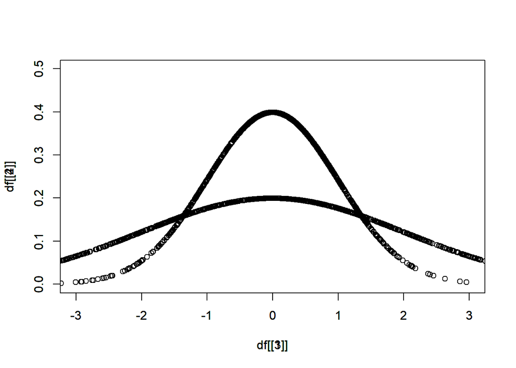

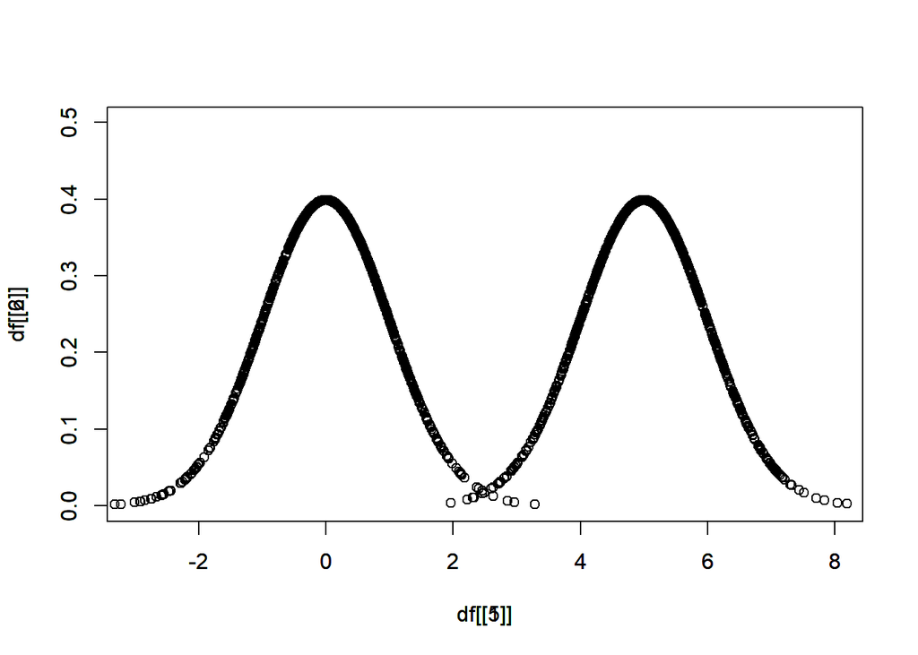

```r
df <- data.frame(
  matrix(0, nrow = 1000, ncol = 2))

df[[1]] <- rnorm(n = 1000, mean = 0, sd = 1)
df[[2]] <- dnorm(df[[1]], mean = 0, sd = 1)
```

`rnorm()` 隨機抽樣

`dnorm()` 抽出樣本的機率

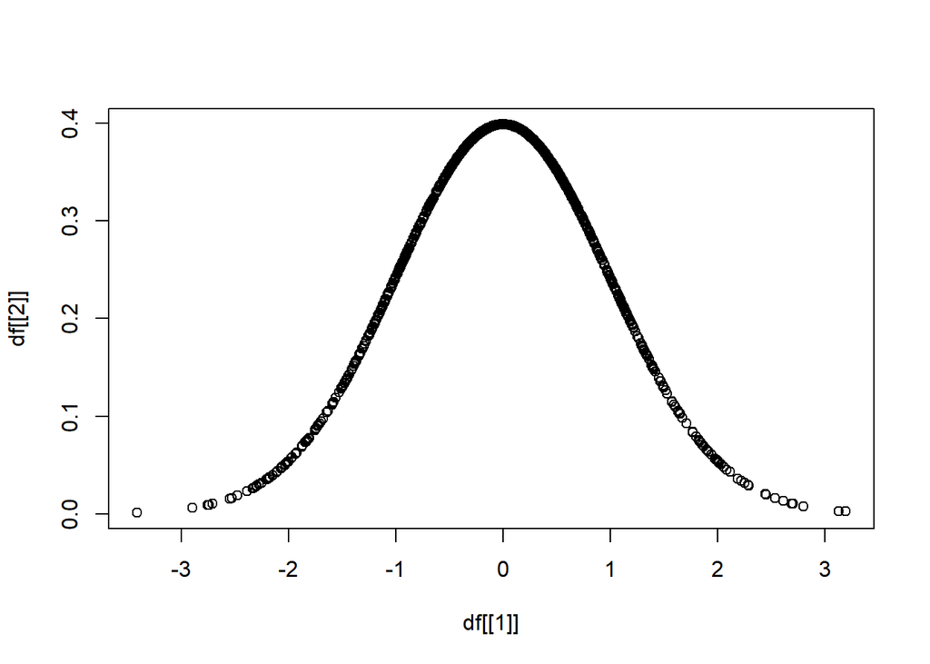

```r
plot(x = df[[1]], y = df[[2]])
```

依此類推，分別對三種分布抽出 1000 個樣本。

```r
df <- data.frame(
  matrix(0, nrow = 1000, ncol = 6))

df[[1]] <- rnorm(1000, mean = 0, sd = 1)
df[[2]] <- dnorm(df[[1]], mean = 0, sd = 1)
df[[3]] <- rnorm(____, mean = 0, sd = 2)
df[[4]] <- dnorm(____, mean = 0, sd = 2)
df[[5]] <- rnorm(____, mean = 5, sd = 1)
df[[6]] <- dnorm(____, mean = 5, sd = 1)
```

知道函數 argument 的順序，可以省略 argument。

```r
# 這兩個一樣
df[[1]] <- rnorm(1000, mean = 0, sd = 1)
df[[1]] <- rnorm(1000, 0, 1)
```

第一小題，在比較相同的平均值，不同的標準差的時候，會需要疊圖，疊圖的方法是使用 `par(new = T)`，

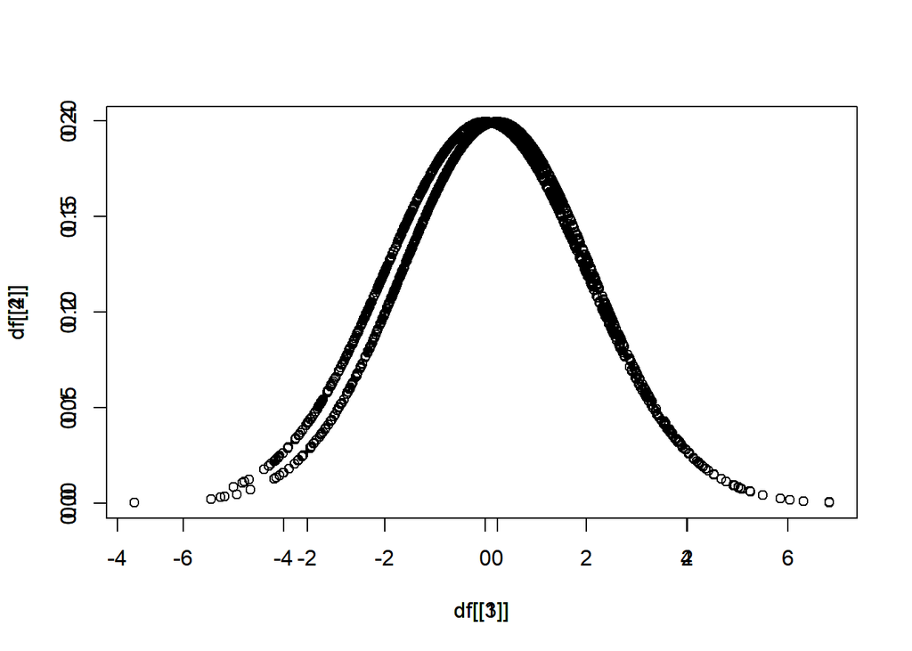

```r
plot(x = df[[1]], y = df[[2]])
par(new = T)
plot(x = df[[3]], y = df[[4]])
```

但是尺度可能不一樣，用 `xlim()`，`ylim()` 限制範圍。

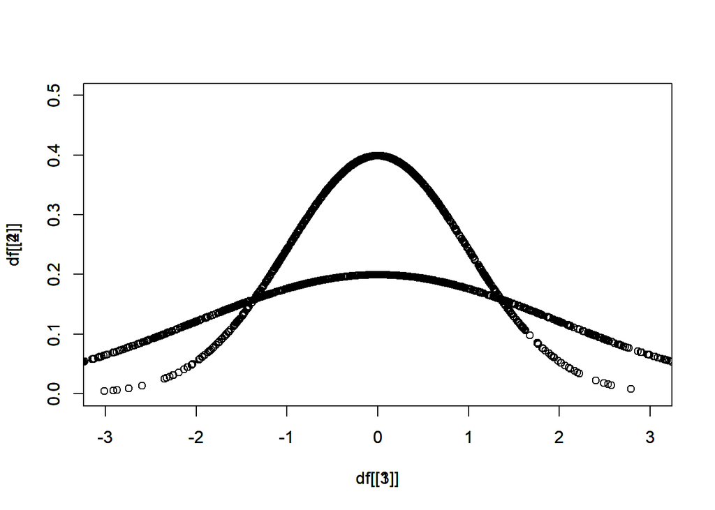

```r
plot(x = df[[1]], y = df[[2]], xlim = c(-3,3), ylim = c(0,0.5))
par(new = T)
plot(x = df[[3]], y = df[[4]], xlim = c(-3,3), ylim = c(0,0.5))
```

以此類推，第二小題，

```r
plot(x = df[[1]], y = df[[2]], xlim = c(__,__), ylim = c(__,__))
par(new = T)
plot(x = _______, y = _______, xlim = c(__,__), ylim = c(__,__))
```

# 10/24 統計圖表繪製

## Review

[Find the **Base R** cheetsheet](https://rstudio.com/resources/cheatsheets/)

承 10/17 實習課的內容，介紹進階的資料視覺化方法。

## 學習目標

介紹 `plot()` 和 `ggplot()` 的做法。

## `plot()`

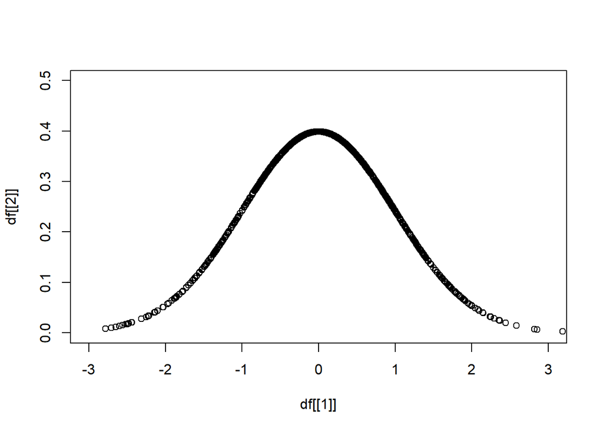

```r
df <- data.frame(
  matrix(0, nrow = 1000, ncol = 2))

df[[1]] <- rnorm(1000, mean = 0, sd = 1)
df[[2]] <- dnorm(df[[1]], mean = 0, sd = 1)

plot(x = df[[1]], y = df[[2]],
     xlim = c(-3,3), ylim = c(0,0.5))
```

```r
head(df)
```

```
#>            X1        X2
#> 1  0.83835721 0.2807306
#> 2  0.06558557 0.3980852
#> 3 -0.09354602 0.3972005
#> 4 -0.45119162 0.3603334
#> 5 -0.79209819 0.2915195
#> 6 -0.08641840 0.3974554
```

圖表標題，`main = "__"`，

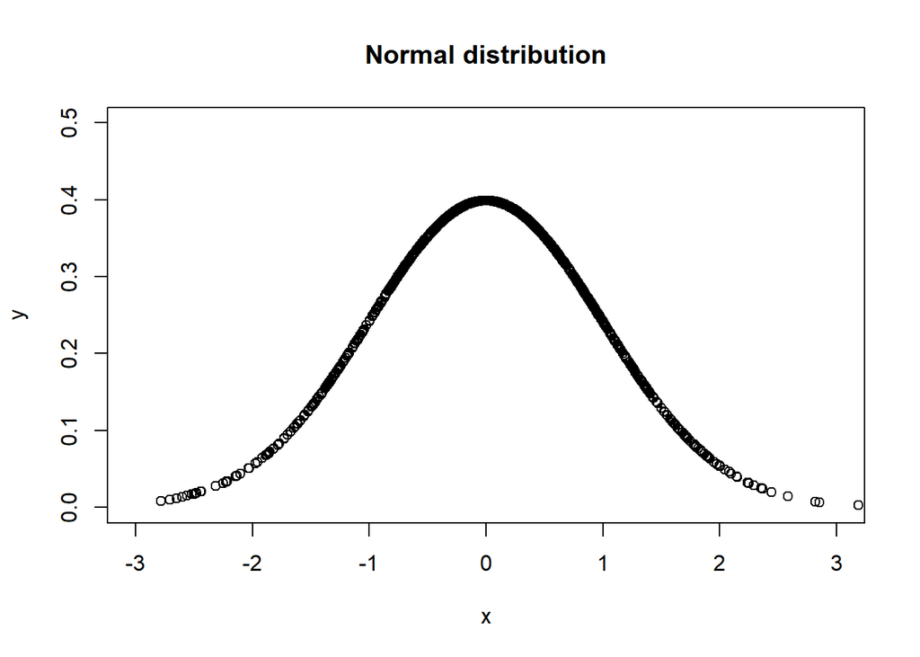

```r
plot(x = df[[1]], y = df[[2]],
     xlim = c(-3,3), ylim = c(0,0.5),
     main = "Normal distribution",
     xlab = "x", ylab = "y")
```

更改坐標軸名稱，`xlab = "__"`，`ylab = "__"`，

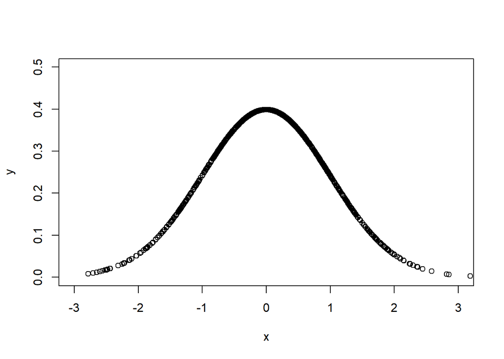

```r
plot(x = df[[1]], y = df[[2]],
     xlim = c(-3,3), ylim = c(0,0.5),
     xlab = "x", ylab = "y")
```

顏色 `col = "____"`，

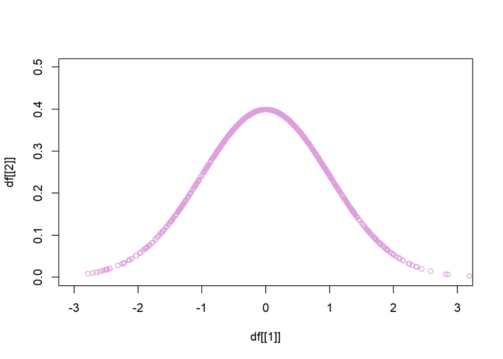

```r
plot(x = df[[1]], y = df[[2]],
     xlim = c(-3,3), ylim = c(0,0.5),
     col = "plum")
```

點的形狀 `pch = 20`，

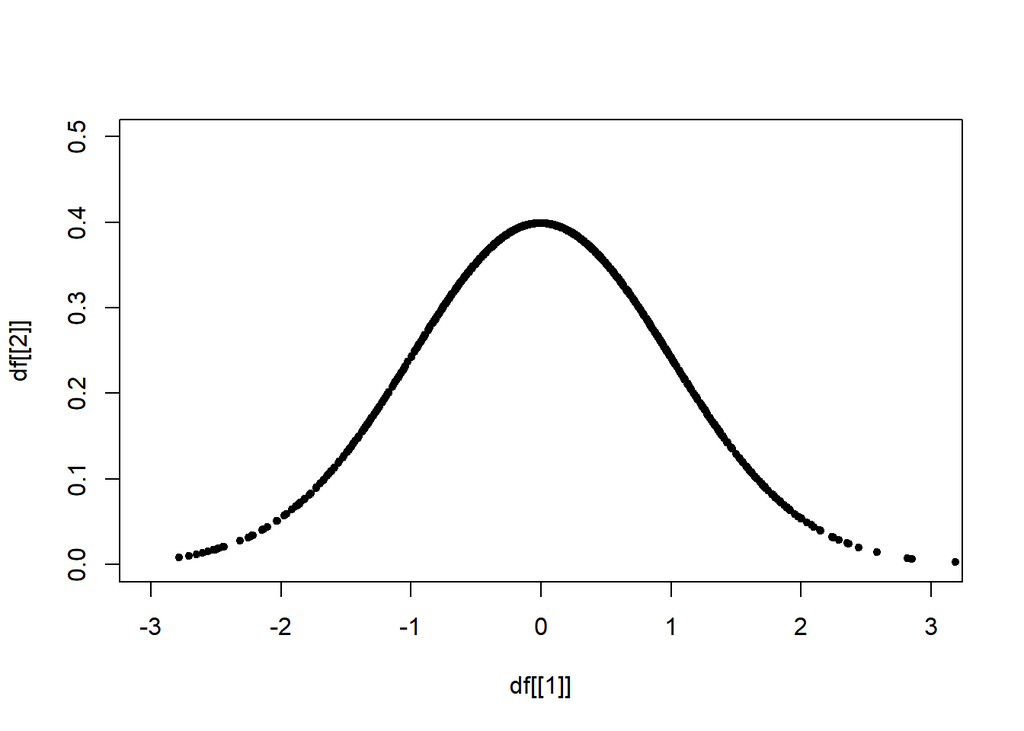

```r
plot(x = df[[1]], y = df[[2]],
     xlim = c(-3,3), ylim = c(0,0.5),
     pch = 20)
```

## `ggplot()`

[Find the **Data Visualization Cheat Sheet**](https://rstudio.com/resources/cheatsheets/)

```r
install.packages("ggplot2")
library(ggplot2)
```

```r
head(df)
```

```
#>            X1        X2
#> 1  0.83835721 0.2807306
#> 2  0.06558557 0.3980852
#> 3 -0.09354602 0.3972005
#> 4 -0.45119162 0.3603334
#> 5 -0.79209819 0.2915195
#> 6 -0.08641840 0.3974554
```

基本

```r
ggplot(data = df) +
  geom_point(mapping = aes(X1, X2))
```

或者也可以寫成

```r
ggplot(df) +
  geom_point(aes(X1, X2))
```

坐標軸名稱與圖表標題

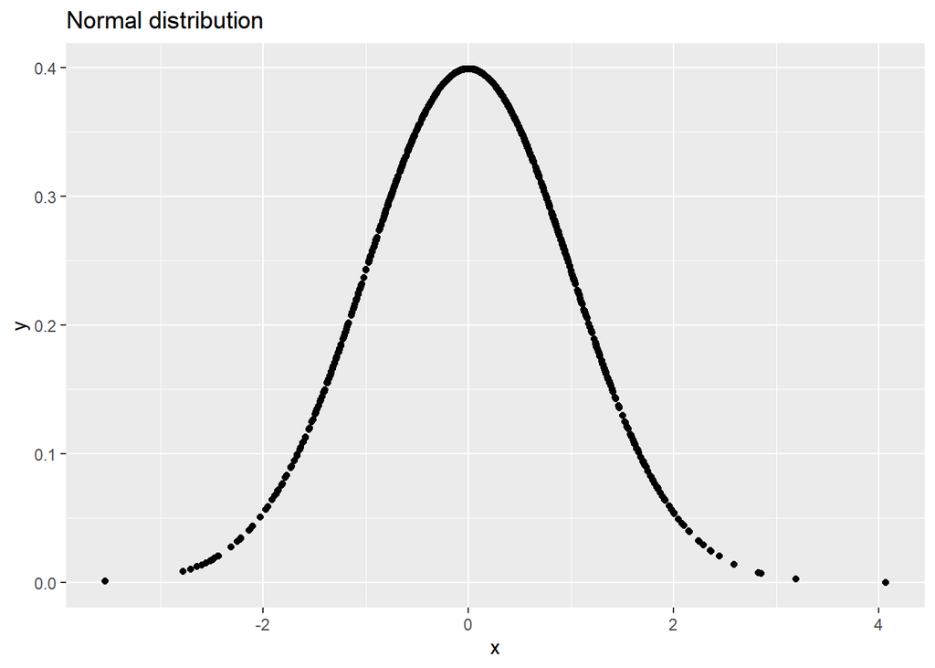

```r
ggplot(data = df) +
  geom_point(mapping = aes(X1, X2)) +
  labs(x = "x", y = "y", title = "Normal distribution")
```

注意 argument 順序

```r
ggplot(df) +
  geom_point(aes(X1, X2)) +
  labs("Normal distribution", "x", "y")
```

座標軸範圍限制

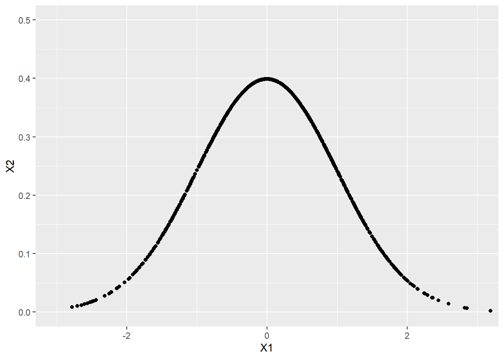

```r
ggplot(data = df) +
  geom_point(mapping = aes(X1, X2)) +
  coord_cartesian(xlim = c(-3, 3), ylim = c(0, 0.5))
```

顏色

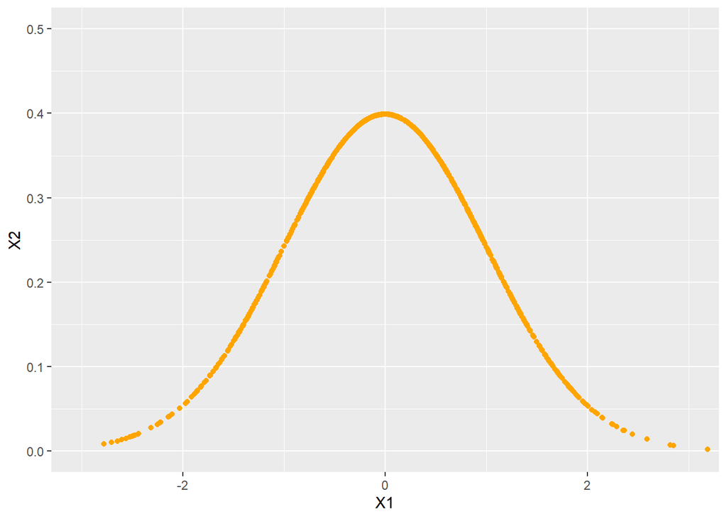

```r
ggplot(data = df) +
  geom_point(mapping = aes(X1, X2), color = "orange") +
  coord_cartesian(xlim = c(-3, 3), ylim = c(0, 0.5))
```

畫圖主題

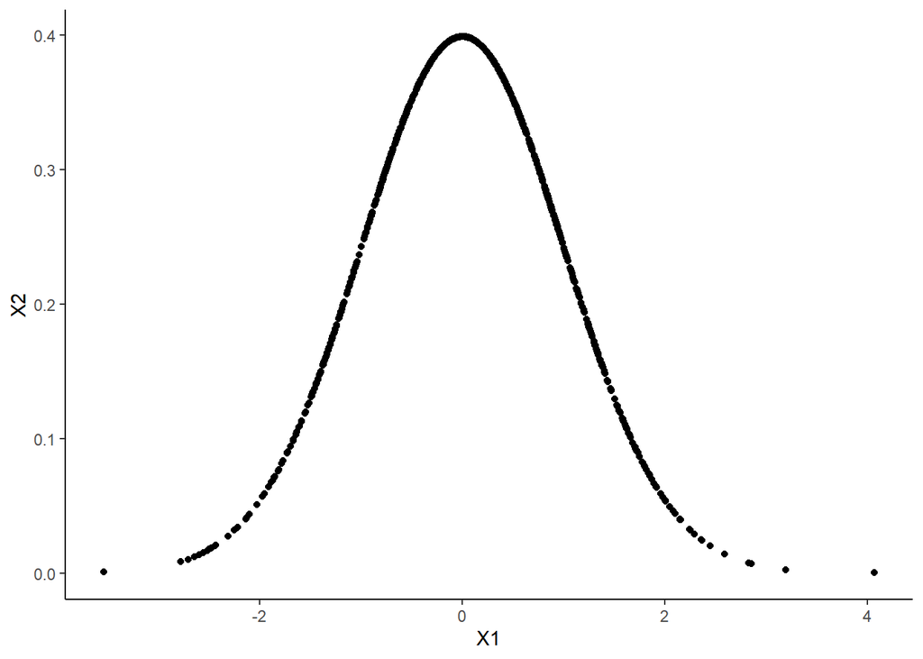

```r
ggplot(data = df) +
  geom_point(mapping = aes(X1, X2)) +
  theme_classic()
```

疊圖方法

```r
ggplot(data = df) +
  geom_point(mapping = aes(X1, X2)) +
  geom_point(mapping = aes(X3, X4)) +
  theme_classic()
```

## 習題

進一步視覺化 10/17 實習的題目，包括 (1) 圖表標題 (2) 坐標軸名稱 (3) 顏色

分別從 $N(\mu = 0, \sigma = 1)$、$N(\mu = 0, \sigma = 2)$、$N(\mu = 5, \sigma = 1)$ 抽出 1000 個樣本。

其中，$N$ 表示常態分佈，$\mu$ 表示平均值，$\sigma$ 表示標準差。

畫圖比較

1. 相同的平均值，不同的標準差
2. 不同的平均值，相同的標準差

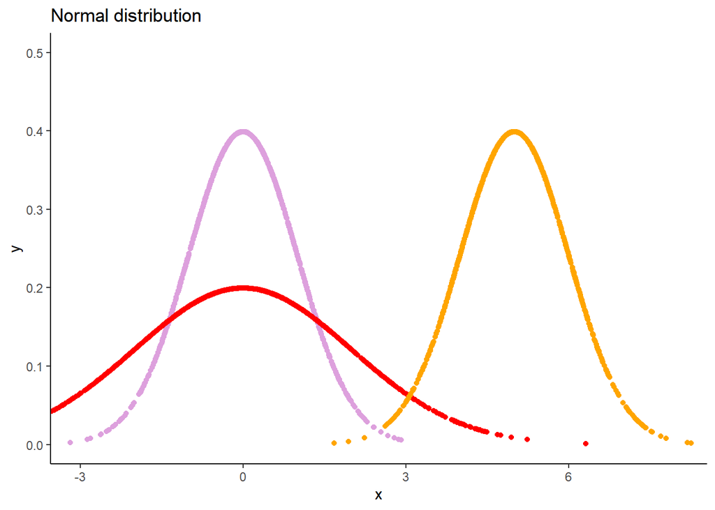

# 10/31 區間估計

## 學習目標

了解 `qnorm()` 和在 R 取“部分”的方法。

```r
qnorm(0, 0, 1)
```

```
#> [1] -Inf
```

```r
qnorm(0.25, 0, 1)
```

```
#> [1] -0.6744898
```

```r
qnorm(0.50, 0, 1)
```

```
#> [1] 0
```

```r
qnorm(0.75, 0, 1)
```

```
#> [1] 0.6744898
```

```r
qnorm(1, 0, 1)
```

```
#> [1] Inf
```

從簡單的樣本出發，

```r
df <- data.frame(
  matrix(0, nrow = 10, ncol = 2))

df[[1]] <- rnorm(10, mean = 0, sd = 1)
df[[2]] <- dnorm(df[[1]], mean = 0, sd = 1)
```

```
#>            X1        X2
#> 1   1.2402527 0.1848793
#> 2  -0.2999905 0.3813889
#> 3  -0.2146775 0.3898545
#> 4  -0.1665791 0.3934455
#> 5  -1.6501283 0.1022433
#> 6   1.5626566 0.1176682
#> 7  -0.8266400 0.2834824
#> 8   0.3113138 0.3800712
#> 9  -1.0203888 0.2370379
#> 10 -0.1154959 0.3962903
```

取出小於 25 百分位的樣本，注意逗點位置，

```r
df[df$X1 < qnorm(0.25, 0, 1),]
```

```
#>          X1        X2
#> 5 -1.650128 0.1022433
#> 7 -0.826640 0.2834824
#> 9 -1.020389 0.2370379
```

```r
df[df[[1]] < qnorm(0.25, 0, 1),]
```

```
#>          X1        X2
#> 5 -1.650128 0.1022433
#> 7 -0.826640 0.2834824
#> 9 -1.020389 0.2370379
```

兩個以上的條件，`&` 表示“且”，`|` 表示“或”，取出小於 25 百分位的樣本**或**大於 75百分位的樣本。

```r
df[df$X1 < qnorm(0.25, 0, 1) | df$X1 > qnorm(0.75, 0, 1),]
```

```
#>          X1        X2
#> 1  1.240253 0.1848793
#> 5 -1.650128 0.1022433
#> 6  1.562657 0.1176682
#> 7 -0.826640 0.2834824
#> 9 -1.020389 0.2370379
```

## 習題

從 $N(\mu = 0, \sigma = 1)$ 抽出 1000 個樣本，找出其雙尾 95% 信賴區間，區間內的樣本以紅色表示。

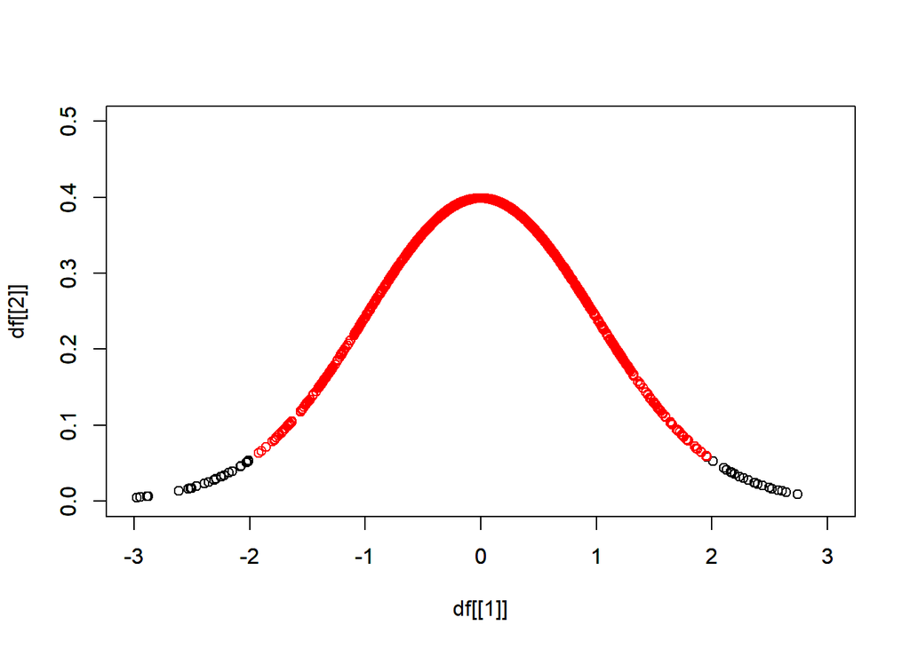